# Homework 3

Olivia Quinn

4/12/2022

Packages

```r
library(tidymodels)
library(tidyverse)
library(readr)
library(corrr)
library(discrim)
library(poissonreg)
library(klaR)
tidymodels_prefer()
```

Load and Tidy Data

```r
titanic <- read_csv("data/titanic.csv")

titanic$survived <- factor(titanic$survived, levels = c('Yes', 'No'))
titanic$pclass <- factor(titanic$pclass)
```

### Question 1

It is a good idea to use stratified sampling because it ensures that the group that survived and the group that did not receive proper representation in our training and testing data sets. Many more people did not survive than did survive.

Potential issues: Quite a bit of missing data, mostly on passenger age and cabin.

```r
set.seed(24)

titanic %>%
  count(survived)
```

```
## # A tibble: 2 × 2
##   survived     n
##   <fct>    <int>
## 1 Yes        342
## 2 No         549
```

```r
titanic_split <- initial_split(titanic, prop = 0.70,
                                strata = survived)
titanic_train <- training(titanic_split)
titanic_test <- testing(titanic_split)

titanic_train %>%
  summarise(count = sum(is.na(titanic_train)))
```

```
## # A tibble: 1 × 1
##   count
##   <int>
## 1   619
```

### Question 2

A bar plot of the outcome variable ‘survived’ reveals that the majority of passengers aboard the Titanic did not survive.

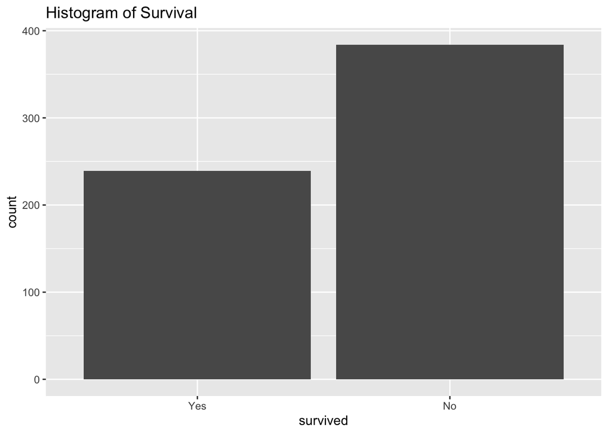

```r
ggplot(titanic_train, aes(survived)) +
  geom_bar() +
  labs(title= "Histogram of Survival")
```

### Question 3

Number of parents and children aboard is positively associated with number of siblings and spouses aboard and with passenger fare. Age is negatively correlated with both number of siblings and spouses aboard and number of parents and children aboard. Fare is weakly positively associated with number of parents and children aboard.

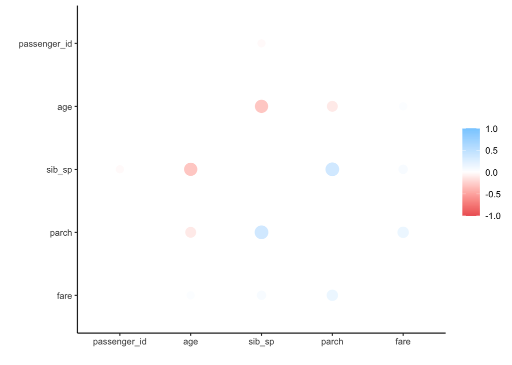

```r
cor_titanic <- correlate(titanic_train[, sapply(titanic_train, is.numeric)], use = "complete.obs")
rplot(cor_titanic)
```

### Question 4

Recipe.

```r
titanic_recipe <- recipe(survived ~ pclass + sex + age + sib_sp + parch +
                           fare, data = titanic_train) %>%
  step_impute_linear(age, impute_with = imp_vars(all_predictors())) %>%
  step_dummy(all_nominal_predictors()) %>%
  step_interact(terms = ~ fare:starts_with("sex")) %>%
  step_interact(terms = ~ fare:age)

summary(titanic_recipe)
```

```
## # A tibble: 7 × 4
##   variable type    role      source
##   <chr>    <chr>   <chr>     <chr>
## 1 pclass   nominal predictor original
## 2 sex      nominal predictor original
## 3 age      numeric predictor original
## 4 sib_sp   numeric predictor original
## 5 parch    numeric predictor original
## 6 fare     numeric predictor original
## 7 survived nominal outcome   original
```

### Question 5

Logistic regression model + workflow + fit to training data.

```r
log_reg <- logistic_reg() %>%
  set_engine("glm") %>%
  set_mode("classification")

log_wkflow <- workflow() %>%
  add_model(log_reg) %>%
  add_recipe(titanic_recipe)

log_fit <- fit(log_wkflow, titanic_train)
```

### Question 6

Linear discriminant analysis model + workflow + fit to training data.

```r
lda_mod <- discrim_linear() %>%
  set_mode("classification") %>%
  set_engine("MASS")

lda_wkflow <- workflow() %>%
  add_model(lda_mod) %>%
  add_recipe(titanic_recipe)

lda_fit <- fit(lda_wkflow, titanic_train)
```

### Question 7

Quadratic discriminant analysis model + workflow + fit to training data.

```r
qda_mod <- discrim_quad() %>%
  set_mode("classification") %>%
  set_engine("MASS")

qda_wkflow <- workflow() %>%
  add_model(qda_mod) %>%
  add_recipe(titanic_recipe)

qda_fit <- fit(qda_wkflow, titanic_train)
```

### Question 8

Naive Bayes model + workflow + fit to training data.

```r
nb_mod <- naive_Bayes() %>%
  set_mode("classification") %>%
  set_engine("klaR") %>%
  set_args(usekernel = FALSE)

nb_wkflow <- workflow() %>%
  add_model(nb_mod) %>%
  add_recipe(titanic_recipe)

nb_fit <- fit(nb_wkflow, titanic_train)
```

### Question 9

Predictions + Accuracies for all 4 models.

```r
log_predict <- predict(log_fit, new_data = titanic_train, type = "class")
lda_predict <- predict(lda_fit, new_data = titanic_train, type = "class")
qda_predict <- predict(qda_fit, new_data = titanic_train, type = "class")
nb_predict <- predict(nb_fit, new_data = titanic_train, type = "class")

compare_predict <- bind_cols(log_predict, lda_predict, qda_predict, nb_predict, titanic_train$survived)

log_reg_acc <- augment(log_fit, new_data = titanic_train) %>%
  accuracy(truth = survived, estimate = .pred_class)

lda_acc <- augment(lda_fit, new_data = titanic_train) %>%
  accuracy(truth = survived, estimate = .pred_class)

qda_acc <- augment(qda_fit, new_data = titanic_train) %>%
  accuracy(truth = survived, estimate = .pred_class)

nb_acc <- augment(nb_fit, new_data = titanic_train) %>%
  accuracy(truth = survived, estimate = .pred_class)
```

The logistic regression model achieved the highest accuracy on the training data (0.82).

```r
accuracies <- c(log_reg_acc$.estimate, lda_acc$.estimate,
                nb_acc$.estimate, qda_acc$.estimate)
models <- c("Logistic Regression", "LDA", "Naive Bayes", "QDA")
results <- tibble(accuracies = accuracies, models = models)
results %>%
  arrange(-accuracies)
```

```
## # A tibble: 4 × 2
##   accuracies models
##        <dbl> <chr>
## 1      0.819 Logistic Regression
## 2      0.814 LDA
## 3      0.814 QDA
## 4      0.804 Naive Bayes
```

### Question 10

Fitting the logistic regression model to the testing data.

```r
predict(log_fit, new_data = titanic_test, type = "class")
```

```
## # A tibble: 268 × 1
##    .pred_class
##    <fct>
##  1 No
##  2 No
##  3 Yes
##  4 Yes
##  5 Yes
##  6 No
##  7 No
##  8 Yes
##  9 No
## 10 Yes
## # … with 258 more rows
```

The testing accuracy of the logistic regression model rounds up to 0.81. The training accuracy of the same model rounds up to 0.82. The model performs fairly well with nearly identical training and testing accuracies.

```r
multi_metric <- metric_set(accuracy, sensitivity, specificity)

augment(log_fit, new_data = titanic_test) %>%
  multi_metric(truth = survived, estimate = .pred_class)
```

```
## # A tibble: 3 × 3
##   .metric     .estimator .estimate
##   <chr>       <chr>          <dbl>
## 1 accuracy    binary         0.806
## 2 sensitivity binary         0.641
## 3 specificity binary         0.909
```

Confusion Matrix.

```r
augment(log_fit, new_data = titanic_test) %>%
  conf_mat(truth = survived, estimate = .pred_class)
```

```
##           Truth
## Prediction Yes  No
##        Yes  66  15
##        No   37 150
```

ROC curve.

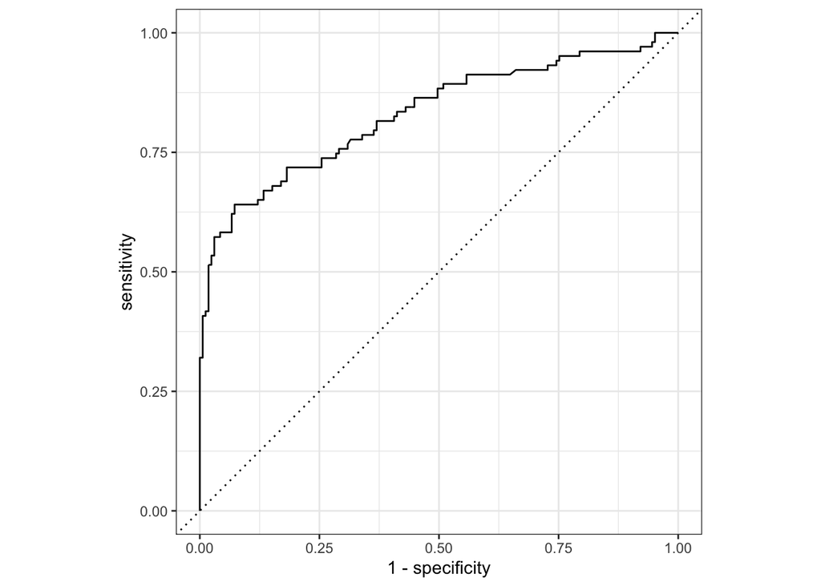

```r
augment(log_fit, new_data = titanic_test) %>%
  roc_curve(survived, .pred_Yes) %>%
  autoplot()
```

Area Under the Curve = 0.83

```r
augment(log_fit, new_data = titanic_test) %>%
  roc_auc(survived, .pred_Yes)
```

```
## # A tibble: 1 × 3
##   .metric .estimator .estimate
##   <chr>   <chr>          <dbl>
## 1 roc_auc binary         0.830
```

### 231 Questions

In a binary classification problem, let $p$ represent the probability of class label $1$, which implies that $1 - p$ represents the probability of class label $0$. The *logistic function* (also called the “inverse logit”) is the cumulative distribution function of the logistic distribution, which maps a real number *z* to the open interval $(0, 1)$.

### Question 11

The *logit* function…

$$z(p)=ln\left(\frac{p}{1-p}\right)$$
…is equivalent to:
$$e^z = \left(\frac{p}{1-p}\right)
\\
e^z(1-p) = p
\\
e^z - (p)(e^z) = p
\\
e^z = p + (p)(e^z)
\\
e^z = p(1+e^z)
\\
p = \left(\frac{e^z}{1+e^z}\right)$$

### Question 12

#### Assume that $z = \beta_0 + \beta_{1}x_{1}$ and $p = logistic(z)$. How do the odds of the outcome change if you increase $x_{1}$ by two? Demonstrate this.

Under the simple logistic regression model of:

$$ln\left(\frac{p}{1-p}\right) = \beta_0 + \beta_{1}x_{1}$$
This means that when $x=0$, the log odds are equal to $\beta_0$.

Also, this means that for every one unit increase in $x$ the log odds increases by $\beta_1$. A *two* unit increase in $x$ results in an increase to the log odds of $2\beta_1$.

Additionally, given that $odds = e^{\beta_0 + \beta_1x}$, which is equivalent to $odds = e^{\beta_0} * e^{\beta_1x}$… a one unit increase (from 0 to 1) in x results in multiplying the odds by $e^{\beta_1}$. A two unit increase (from 0 to 2) results in multiplying the odds by $e^{2\beta_1}$.

#### Assume now that $\beta_1$ is negative. What value does $p$ approach as $x_{1}$ approaches $\infty$? What value does $p$ approach as $x_{1}$ approaches $-\infty$?

If $\beta_1$ is negative, $p$ approaches 0 as $x_{1}$ approaches $\infty$ and $p$ approaches 1 as $x_{1}$ approaches $-\infty$.